# Investigating asymmetry in PRS in the complex demography model

##Introduction

I have observed that when GWAS is simulated under the model with complex demography, the predicted PRS is more structured in the North-South direction that in the East-West direction. This is understandable because there is more structure in the N-S direction (ancient structure due to admixture between NHG and SHG). However, we expect the structure in the E-W direction to be similar to that in the $\tau = 100$ model. This does not appear to be the case as the correlation between PRS (for a smooth effect in the E-W direction) and longitude in the complex demography model is less than the correlation under tha $\tau = 100$ model.

I think this has something to do with differences in genetic architecture (of the phenotype) between the two models. I expect there to be more common variants under the complex demography model (because of ancient structure) than in the $\tau = 100$ model. Also, these ‘extra’ common variants should be more structured in the N-S direction. Because of this, I expect more of the genetic variance of the trait to be driven by common variants structured in the N-S direction under the complex demography model compared to the $\tau = 100$ model. Therefore, we expect the (true) PRS to be structured more in the N-S direction than in the E-W direction. Let’s test some of these ideas.

First, let’s test whether the SFS spectrum of the causl variants is different between the two models in that there are more common variants under the complex demography model than under the $\tau = 100$ model.

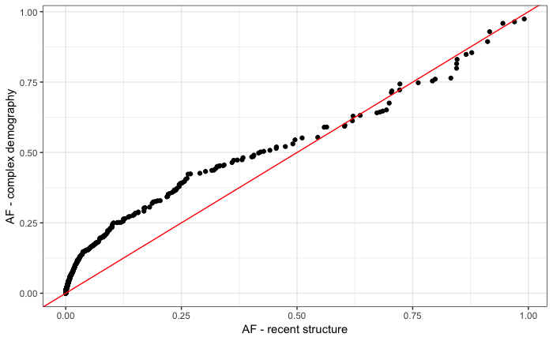

Clearly the SFS is different between the two models. The complex demography model has more common variants than the recent structure model.

Next, let’s test whether there is more structure in the N-S direction under complex demography model.

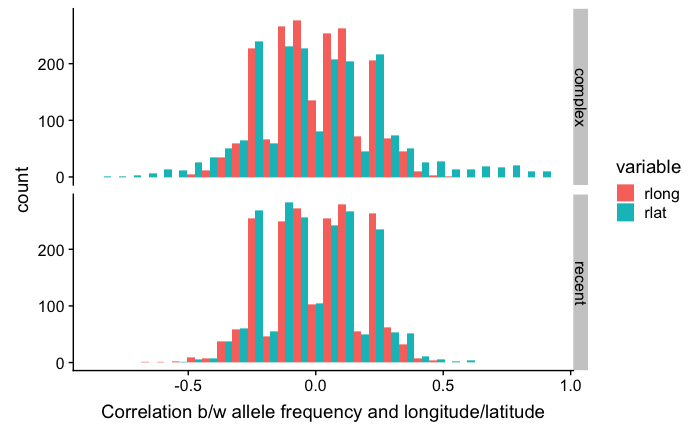

```r
#load frequency per deme
frq.clst1 = fread("gwas/grid/genotypes/tau100/ss500/train/genos_grid_d36_m0.05_s500_t100.rmdup.train.clst.frq.strat")
frq.clst2 = fread("gwas/complex_dem/train/genotypes/genos_complex_l1e7_ss500_m0.07_chr1_20.rmdup.train.snps.thinned_100kb.clst.frq.strat")
#load population file - contains latitude and longitude info for each deme
pop = fread("gwas/complex_dem/genos_complex_l1e7_ss500_m0.07.train.pop")
pop2 = pop%>%
  distinct(deme,longitude,latitude)
frq.clst1 = merge(frq.clst1,
                  pop2,
                  by.x = "CLST",
                  by.y = "deme",
                  all.x=T)
frq.clst2 = merge(frq.clst2,
                  pop2,
                  by.x = "CLST",
                  by.y = "deme",
                  all.x=T)
#calculate the correlation between MAF with longitude and latitude and compare under the two models
frq.clst.r1 = frq.clst1%>%
  group_by(SNP)%>%
  summarize(rlong = cor(MAF,longitude),
            rlat = cor(MAF,latitude))
frq.clst.r2 = frq.clst2%>%
  group_by(SNP)%>%
  summarize(rlong = cor(MAF,longitude),
            rlat = cor(MAF,latitude))
frq.clst.r1 = merge(frq.clst.r1,frq1[,c("ID","ALT_FREQS")],
                    by.x = "SNP",
                    by.y = "ID")
frq.clst.r2 = merge(frq.clst.r2,frq2[,c("ID","ALT_FREQS")],
                    by.x = "SNP",
                    by.y = "ID")
frq.clst.r1$demography = "recent"
frq.clst.r2$demography = "complex"
frq.clst.r = rbind(frq.clst.r1,frq.clst.r2)
mfrq.clst.r = reshape2::melt(frq.clst.r, id.vars=c("SNP","demography","ALT_FREQS"))
#plot historgram of the correlations under the two models
plt_rhist = ggplot(mfrq.clst.r)+
  geom_histogram(aes(value,fill=variable),
                 position="dodge")+
  facet_grid(demography~.)+
  labs(x = "Correlation b/w allele frequency and longitude/latitude")
plt_rhist
```

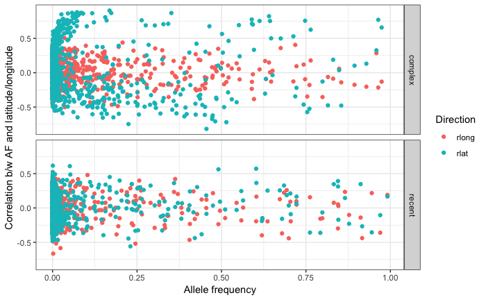

```r
#plot correlation between rlong/rlat and allele frequency to see how structure correlates with allele frequency
plt_rmaf = ggplot(mfrq.clst.r)+
  geom_point(aes(ALT_FREQS,value,color=variable))+
  theme_bw()+
  facet_grid(demography~.)+
  labs(x = "Allele frequency",
       y = "Correlation b/w AF and latitude/longitude",
       color = "Direction")
plt_rmaf
```

A few things are clear from this:

1. (From the histrograms): There is more structure in the N-S direction under the complex demography, as expected. In contrast, the structure is similar in the N-S vs E-W direction under the recent demography.
2. (From the scatterplots): Under the complex demography model, the ‘extra’ N-S structure (based on the correlation between allele frequency and latitude) is driven by common variants. Most variants that are highly correlated with latitude tend to be common.

Next, let’s see if there is more genetic variance in the N-S direction compared to the E-W direction under the complex demography model. This is expected not because the variants in the N-S direction have higher effects per se conditioned on their MAF. It’s because there are more common variants in the N-S direction than in the E-W direction. I have simulated the genetic architecture using the following:

$$\beta_i \sim N(0,\sigma_l^2 [p_i(1-p_i)]^\alpha)$$
Which makes the total genetic variance contributed by a variant equal to
$$\sigma_l^2 2 [p_i(1 - p_i)]^{\alpha+1}$$
In models where $\alpha$ = -1 (e.g. GCTA and LDSC), the genetic variance contributed by each variant is independent of the frequency. In such models, we shouldn’t expect there to be more genetic variance in the N-S direction. But under my model ($\alpha = -0.4$), common variants explain more of the heritability than rare variants.

First, let’s get the simulated genetic effects of each locus and test its relationship to structure.

```r
effects1 = fread("gwas/grid/genotypes/tau100/ss500/train/genos_grid_d36_m0.05_s500_t100.rmdup.train.thinned_100kb.effects")
effects2 = fread("gwas/complex_dem/train/genotypes/genos_complex_l1e7_ss500_m0.07_chr1_20.rmdup.train.snps.thinned_100kb.effects")
colnames(effects1) = colnames(effects2) = c("SNP","e_allele","e_size")
effects1$demography = "recent"
effects2$demography = "complex"
effects = rbind(effects1,effects2)
mfrq.clst.r = merge(mfrq.clst.r, effects, by=c("SNP","demography"))
mfrq.clst.r = mfrq.clst.r%>%
  mutate(GV = e_size^2*(2*ALT_FREQS*(1-ALT_FREQS)))
mfrq.clst.r %>%
  mutate(GV.r = GV*(value^2))%>%
  group_by(demography,variable)%>%
  summarize(GV = sum(GV.r))
```

| demography | variable | GV |
| --- | --- | --- |
| complex | rlong | 0.02828230 |
| complex | rlat | 0.16474671 |
| recent | rlong | 0.03537865 |
| recent | rlat | 0.04268226 |

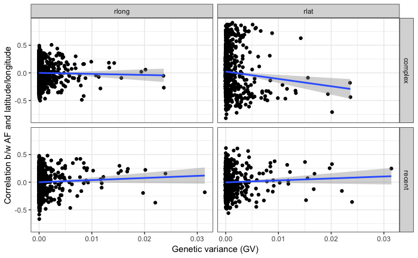

```r
plt_rg = ggplot(mfrq.clst.r)+
  geom_point(aes(GV,value))+
  theme_bw()+
  facet_grid(demography~variable)+
  labs(x = "Genetic variance (GV)",
       y = "Correlation b/w AF and latitude/longitude")+
  scale_color_viridis_c()+
  stat_smooth(aes(GV,value),method="lm")
plt_rg
```

There seems to be a stronger correlation between genetic variance and latitude in the complex demography model but not in the recent demography model, though the effect is not very strong.

Let’s see if the PRS is more strongly correlated with latitude vs longitude.

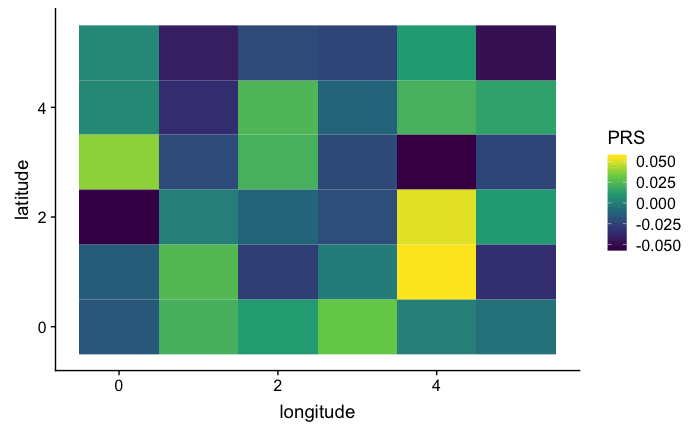